# Analysis of Data from Gaia Space Mission

Mary Fleck

March 23, 2019

This analysis explores data from Gaia Space Mission. The Gaia satellite was commissioned by the European Space Agency to survey over 1 billion stars. The Gaia satellite collects 30 times as much light as its predecessor, Hipparcos, making possible astrometric, photometric, and spectroscopic data that are 200 times more accurate. With this feat comes the steep challenge of processing, manipulating and interpreting the results - three data releases, each larger than the last, released over the span of the seven year mission. The data analyzed here comes from the second data release in 2018. Each observation represents a star.

Variables (in layman’s terms): Right Ascension and Declination - positional information for star Parallax - apparent shift of position (indicative of distance) Proper motion - movement of a star across background space in respect to RA & Dec Magnitude - the brightness of the star Flux - energy emitted per unit area - different variables give flux with peak sensitivity at different wavelengths Error terms give error for all of the above variables Radial Velocity - movement of a star around the detecting object Luminosity - amount of energy emitted from a star per unit of time

More information about the data can be found at https://sci.esa.int/web/gaia.

This code sample specifically showcases three portions of the analysis that helped me to answer the following research question:

In what ways are the relationships between quantities measured by Gaia made evident in the data? How are well-understood dependencies represented in the data? In what ways can less-familiar relationships be expressed?

Three samples are used - one taken from an “pencil-beam” observation from the satellite into the galactic plane, perpendicular to the galactic plane, and mid-way out of the galactic plane. Since there is a much more dense composition of stars in the galactic plain, there is expected to be a greater range of types of stars in this sample than in the others. In some parts, it is useful to compare these samples. In others, we are interested in looking at all of the observations as a whole.

## Cleaning

The following are functions to aid in preparing the raw data for analysis.

Remove units (first row) and convert data to numeric

```r
remove_units <- function(df){
  units <- df[1,] # store units
  df <- df[-c(1:2),]
  map_df(df, function(x) as.numeric(as.character(x)))
}
```

Get complete cases (remove any entries with an NA in any position)

```r
get_cc <- function(df){
  cc <- complete.cases(df)
  df[cc,]
}
```

Remove duplicates (as per dup column)

```r
remove_dup <- function(df){
  dups <- df$Dup == 1
  df[!dups,]
}
```

Find Tukey Outliers

```r
find_outliers <- function(col){
    num5 <- fivenum(col)
    spread4 <- num5[4] - num5[2]
    step <- 2*spread4
    outerfence_Upper <- num5[4] + step
    outerfence_Lower <- num5[2] - step

    outliers <- which(col < outerfence_Lower | col > outerfence_Upper)
    outliers
}
```

Basic cleaning function - report and output

```r
clean_report <- function(df){
  df0 <- remove_units(df)
  cat(nrow(df0), "raw rows", "\n")
  df1 <- remove_dup(df0)
  cat(nrow(df1), "without duplicates", "\n")
  df2 <- get_cc(df1)
  cat(nrow(df2), "complete cases", "\n")
  ggplot(df2, aes(RA_ICRS, DE_ICRS)) + geom_point() + ggtitle("Coordinates of Complete Cases") + xlab("Right Ascension") + ylab("Declination")
}
```

```r
clean_df <- function(df){
  df0 <- remove_units(df)
  df1 <- remove_dup(df0)
  df1
}
```

### Plane Data Set (Set 1)

Data observed in the galactice plane.

```r
plane <- read.csv2("C:\\Users\\MaryF\\OneDrive\\Documents\\Spring Semester 2019\\Honors Project\\plane.tsv")
head(plane)
```

```
##        X_r         X_RAJ2000         X_DEJ2000         RA_ICRS e_RA_ICRS
## 1      deg               deg               deg             deg       mas
## 2 -------- ----------------- ----------------- ---------------   -------
## 3 0.001419 318.0027462283217 +48.3302931996616 318.00272658902    0.1651
## 4 0.001844 318.0018639344788 +48.3291852944469 318.00184814041    0.1664
## 5 0.002269 318.0018160888200 +48.3282671847684 318.00176545408    0.6030
## 6 0.002352 318.0022826877170 +48.3277551934293 318.00228268772    1.7678
##           DE_ICRS e_DE_ICRS              Source        Plx   e_Plx
## 1             deg       mas                            mas     mas
## 2 ---------------   ------- ------------------- ---------- -------
## 3 +48.33027563809    0.1666 2165310721515734528    -0.0831  0.2067
## 4 +48.32917514838    0.1770 2165310717222129920    -0.1399  0.2102
## 5 +48.32825424613    0.6648 2165310721515739008    -0.8001  0.7896
## 6 +48.32775519343    3.3378 2165310721519089536
##        pmRA e_pmRA      pmDE e_pmDE Dup          FG        e_FG    Gmag
```

[output cut: 27 more lines]

```r
plane <- plane[,4:37] #narrow to columns we care about
clean_report(plane)
```

```
## 386777 raw rows
## 376196 without duplicates
## 1255 complete cases
```

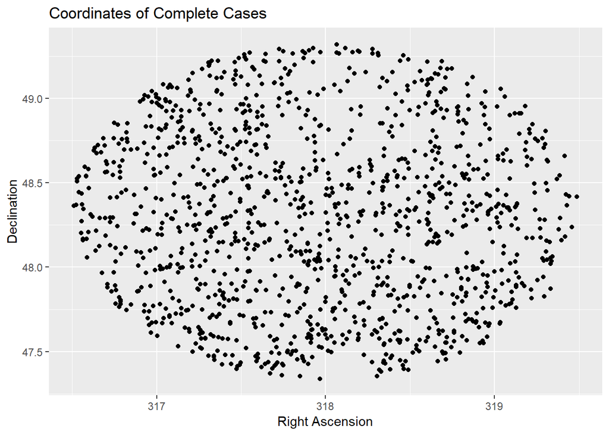

```r
plane_clean <- clean_df(plane)
plane_cc <- get_cc(plane_clean)
```

There are 1255 cases in this sample where there are not any NA values. In plotting these values, it is notable that the observations are randomly spread throughout the field of view of the satellite. This indicates that there was not a systematic error in observation that prevented collection of parameter data for some observations.

### Mid-plane Data Set (Set 2)

Data observed from midway out of the galactic plane.

```r
mid <- read.csv2("C:\\Users\\MaryF\\OneDrive\\Documents\\Spring Semester 2019\\Honors Project\\midplane.tsv")
head(mid)
```

```
##           RA_ICRS e_RA_ICRS         DE_ICRS e_DE_ICRS              Source
## 1             deg       mas             deg       mas
## 2 ---------------   ------- ---------------   ------- -------------------
## 3 240.95101668124    0.2834 +54.83536064322    0.3769 1429179126846060672
## 4 240.97135336497    1.1471 +54.85625043982    2.1667 1429179268580299008
## 5 240.97812790312    0.4579 +54.84376701496    0.5168 1429179229925277568
## 6 240.80622256889    0.8044 +54.82256325953    0.8109 1429179646536643328
##          Plx   e_Plx      pmRA e_pmRA      pmDE e_pmDE Dup          FG
## 1        mas     mas    mas/yr mas/yr    mas/yr mas/yr            e-/s
## 2 ---------- ------- --------- ------ --------- ------   - -----------
## 3    -0.0497  0.3584    -0.778  0.552    -2.351  0.696   0  2.8558e+02
## 4    -0.8556  2.1272     0.632  2.616    -1.630  2.592   1  9.0396e+01
## 5     1.7701  0.4929    -7.870  0.959   -18.361  1.102   0  1.4935e+02
## 6     1.0730  0.8087   -14.093  1.622    -7.458  1.782   0  9.7788e+01
##          e_FG    Gmag e_Gmag         FBP       e_FBP   BPmag e_BPmag
```

[output cut: 20 more lines]

```r
clean_report(mid)
```

```
## 166398 raw rows
## 159338 without duplicates
## 1307 complete cases
```

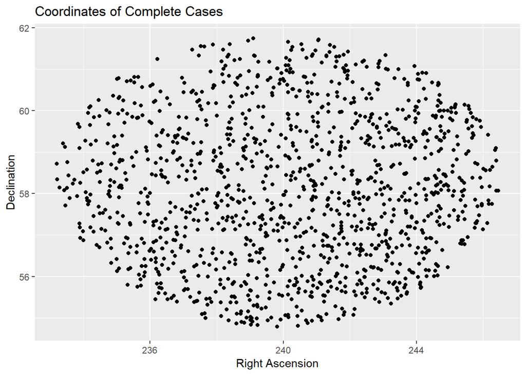

```r
mid_clean <- clean_df(mid)
mid_cc <- get_cc(mid_clean)
```

There are 1307 cases in this sample where there are not any NA values. Just as with the plane sample, we note that the observations are randomly spread throughout the field of view of the satellite.

### Perpendicular data set (Set 3)

Data observed perpendicularly to the galactic plane.

```r
perp <- read.csv2("C:\\Users\\MaryF\\OneDrive\\Documents\\Spring Semester 2019\\Honors Project\\perp.tsv")
head(perp)
```

```
##           RA_ICRS e_RA_ICRS         DE_ICRS e_DE_ICRS              Source
## 1             deg       mas             deg       mas
## 2 ---------------   ------- ---------------   ------- -------------------
## 3 197.35859400555    0.1132 +24.21192692900    0.0932 1447081654342550784
## 4 197.35173893924    1.0307 +24.24708349248    0.7730 1447082066658793088
## 5 197.35130425267    0.0597 +24.23630628736    0.0483 1447082032299673088
## 6 197.36455356054    2.1286 +24.24405512656    1.2271 1447082062363551744
##          Plx   e_Plx      pmRA e_pmRA      pmDE e_pmDE Dup          FG
## 1        mas     mas    mas/yr mas/yr    mas/yr mas/yr            e-/s
## 2 ---------- ------- --------- ------ --------- ------   - -----------
## 3     0.7173  0.1433   -16.072  0.324   -18.556  0.247   0  4.8184e+03
## 4     2.1446  1.2283   -11.361  2.897    -0.093  2.039   0  9.7662e+01
## 5     0.5227  0.0764    -8.735  0.164    -9.892  0.139   0  4.9125e+03
## 6                                                        0  7.6892e+01
##          e_FG    Gmag e_Gmag         FBP       e_FBP   BPmag e_BPmag
```

[output cut: 20 more lines]

```r
clean_report(perp)
```

```
## 204375 raw rows
## 192092 without duplicates
## 1335 complete cases
```

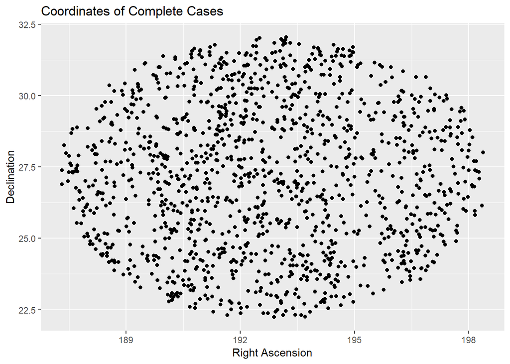

```r
perp_clean <- clean_df(perp)
perp_cc <- get_cc(perp_clean)
```

There are 1335 cases in this sample where there are not any NA values. Just as with the above samples, we note that the observations are randomly spread throughout the field of view of the satellite.

### Combine the three data sets

The numbers of complete cases are very comparable for each sample (~1300 each), which ensures that analysis performed with the combined data set will not be disproportionately representative of one sample.

```r
c1 <- mutate(plane_cc, sample = 1)
c2 <- mutate(mid_cc, sample=2)
c3 <- mutate(perp_cc, sample=3)
all <- rbind(c1, c2, c3)
head(all)
```

```
## # A tibble: 6 x 35
##   RA_ICRS e_RA_ICRS DE_ICRS e_DE_ICRS  Source   Plx  e_Plx   pmRA e_pmRA
##     <dbl>     <dbl>   <dbl>     <dbl>   <dbl> <dbl>  <dbl>  <dbl>  <dbl>
## 1    318.    0.0266    48.3    0.0288 2.17e18 0.314 0.0331  -1.37  0.056
## 2    318.    0.0211    48.4    0.023  2.17e18 0.924 0.0272 -13.6   0.043
## 3    318.    0.0237    48.3    0.0259 2.17e18 0.398 0.0306  -2.22  0.05
## 4    318.    0.0134    48.4    0.0146 2.17e18 0.419 0.0173  -3.61  0.028
## 5    318.    0.0229    48.3    0.0251 2.17e18 1.16  0.0273   8.19  0.045
## 6    318.    0.0195    48.4    0.0234 2.17e18 0.489 0.0257  -4.43  0.04
## # ... with 26 more variables: pmDE <dbl>, e_pmDE <dbl>, Dup <dbl>,
## #   FG <dbl>, e_FG <dbl>, Gmag <dbl>, e_Gmag <dbl>, FBP <dbl>,
## #   e_FBP <dbl>, BPmag <dbl>, e_BPmag <dbl>, FRP <dbl>, e_FRP <dbl>,
## #   RPmag <dbl>, e_RPmag <dbl>, Mode <dbl>, BP.RP <dbl>, RV <dbl>,
## #   e_RV <dbl>, fPriam <dbl>, Teff <dbl>, AG <dbl>, E.BP.RP. <dbl>,
## #   Rad <dbl>, Lum <dbl>, sample <dbl>
```

```r
all <- map_df(all, function(x) as.numeric(as.character(x)))
head(all)
```

```
## # A tibble: 6 x 35
##   RA_ICRS e_RA_ICRS DE_ICRS e_DE_ICRS  Source   Plx  e_Plx   pmRA e_pmRA
##     <dbl>     <dbl>   <dbl>     <dbl>   <dbl> <dbl>  <dbl>  <dbl>  <dbl>
## 1    318.    0.0266    48.3    0.0288 2.17e18 0.314 0.0331  -1.37  0.056
## 2    318.    0.0211    48.4    0.023  2.17e18 0.924 0.0272 -13.6   0.043
## 3    318.    0.0237    48.3    0.0259 2.17e18 0.398 0.0306  -2.22  0.05
## 4    318.    0.0134    48.4    0.0146 2.17e18 0.419 0.0173  -3.61  0.028
## 5    318.    0.0229    48.3    0.0251 2.17e18 1.16  0.0273   8.19  0.045
## 6    318.    0.0195    48.4    0.0234 2.17e18 0.489 0.0257  -4.43  0.04
## # ... with 26 more variables: pmDE <dbl>, e_pmDE <dbl>, Dup <dbl>,
## #   FG <dbl>, e_FG <dbl>, Gmag <dbl>, e_Gmag <dbl>, FBP <dbl>,
## #   e_FBP <dbl>, BPmag <dbl>, e_BPmag <dbl>, FRP <dbl>, e_FRP <dbl>,
## #   RPmag <dbl>, e_RPmag <dbl>, Mode <dbl>, BP.RP <dbl>, RV <dbl>,
## #   e_RV <dbl>, fPriam <dbl>, Teff <dbl>, AG <dbl>, E.BP.RP. <dbl>,
## #   Rad <dbl>, Lum <dbl>, sample <dbl>
```

Plot coordinates in 2D

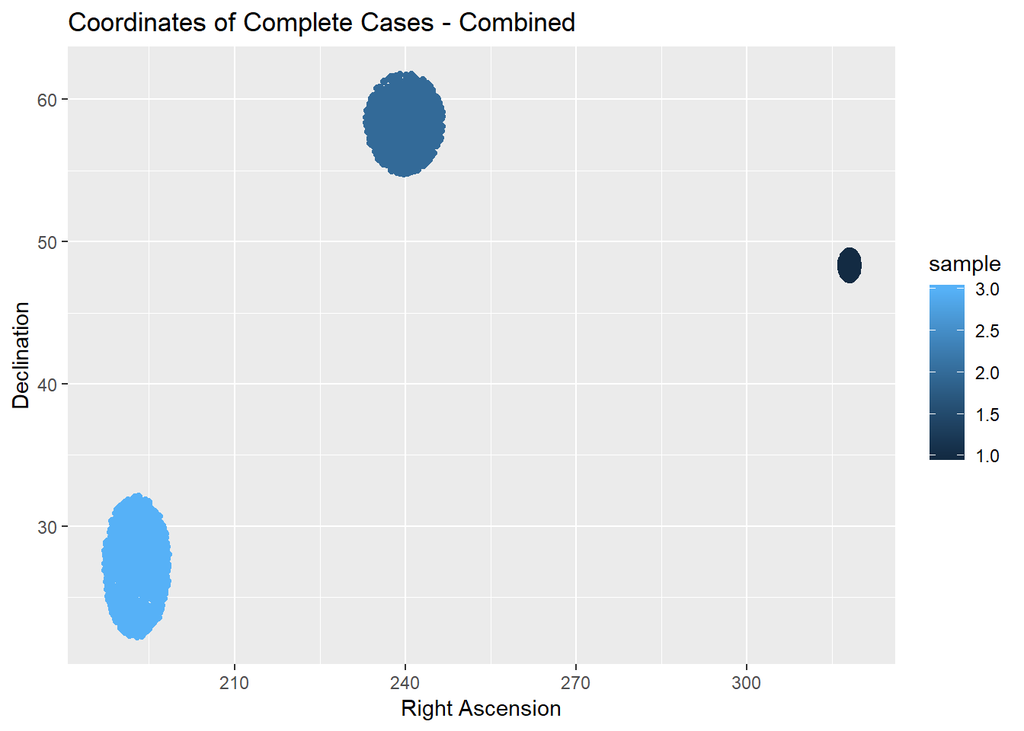

```r
ggplot(all, aes(RA_ICRS, DE_ICRS, color=sample))+ geom_point() + ggtitle("Coordinates of Complete Cases - Combined") + xlab("Right Ascension") + ylab("Declination")
```

In this plot, the bottom right corner of the plot would be the center of the galactic plane, and the reader can imagine a beam cast from that center out to each circle. This is one way to imagine how Gaia collects stellar data.

In order for each of the samples to contain a similar number of complete cases, a smaller aperture (diameter field of view) sample needed to be taken from the galactic plane because there is such a large concentration of stars there. Outside of the galactic plane, however, stars are not observed as densely, so wider aperture samples are taken.

# Analysis

## Part 1: Magnitude and Flux

For part 1 of this analysis, I seek to compare the relationship between magnitude (Gmag), which is the brightness of the star, and flux (FRP), which is the energy emitted per unit area, across samples.

Since I seek to compare this relationship across samples, the code is written functionally.

I begin by expressing the relationship on a scatter plot. Magnitude and flux have a log relationship.

```r
mag_flux <- function(df, title){
  plot <- ggplot(df, aes(FRP, Gmag)) + geom_point() + stat_smooth(method='nls', method.args = list(start = c(a=1, b=1)), formula=y~a*log(x)+b, se=F) + ggtitle(paste(title, '- Flux vs. Magnitude')) + xlab("Flux") + ylab("Magnitude")
  print(plot)
}
```

In order to best analyze the quality of the fit, I transform the data and then analyze the relationship as if it were linear.

I then fit a linear model and analyze the residuals. How much deviation is there from this model? Does the log relationship explain the variation in flux?

Based on what the science tells us about magnitude and flux, deviation from the log relationship should correlate with color index BP-RP. The bluer the color index, the more scatter should exist in the observation.

```r
linear_reexpression <- function(df, title){
  reex <- mutate(df, FRP.reex = FRP ^ (0.0001)) #reexpress col

  plot1 <- ggplot(reex, aes(FRP.reex, Gmag)) + geom_point(alpha=0.3) + ggtitle(paste(title, "- Re-expressed R Flux vs. Magnitude")) + xlab("Re-expressed Flux") + ylab("Magnitude")

  model1 <- lm(Gmag~FRP.reex, data=reex)
  residuals1 <- model1$residuals
  plot2 <- plot(model1)


  reex_r <- data.frame(reex, residuals1)
  plot3 <- ggplot(reex_r, aes(residuals1, BP.RP)) + geom_point(alpha=0.3) + ggtitle(paste(title, "- Residuals from Linear Model vs. Color Index")) + xlab("Residuals") + ylab("Color Index")
  corr1 <- cor(residuals1, reex$BP.RP)


  print(plot1)
  print(plot2)
  print(plot3)
  print(corr1)
}
```

```r
magflux_analysis <- function(df, title){
  #narrow to only relevant columns
  m_fl <- df[,c("Gmag", "FG", "FBP", "FRP", "BP.RP")]

  mag_flux(m_fl, title)

  linear_reexpression(m_fl, title)
}
```

Executing for the first sample:

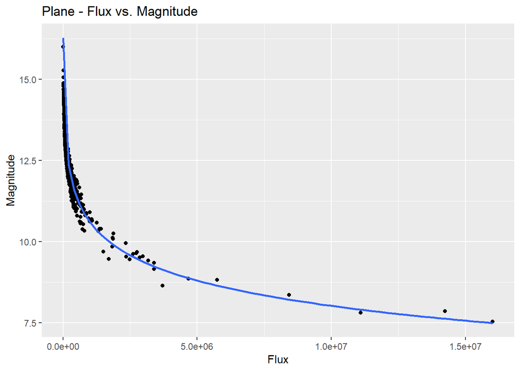

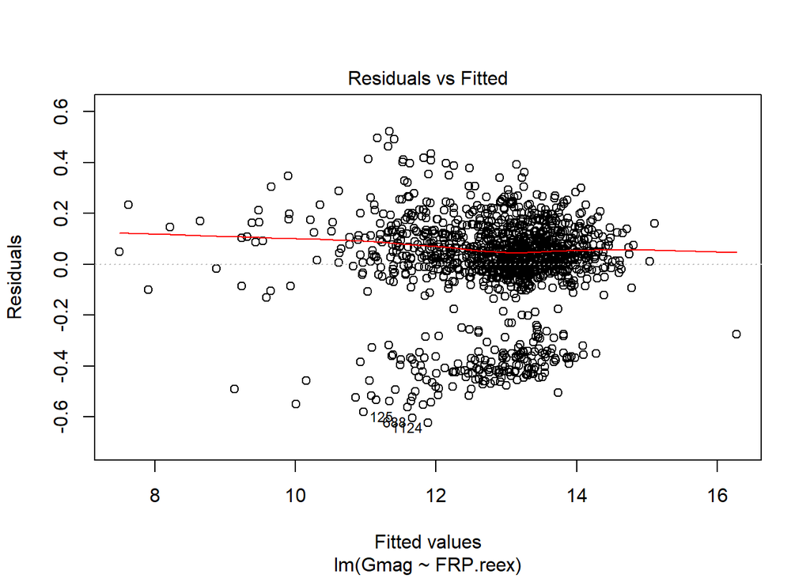

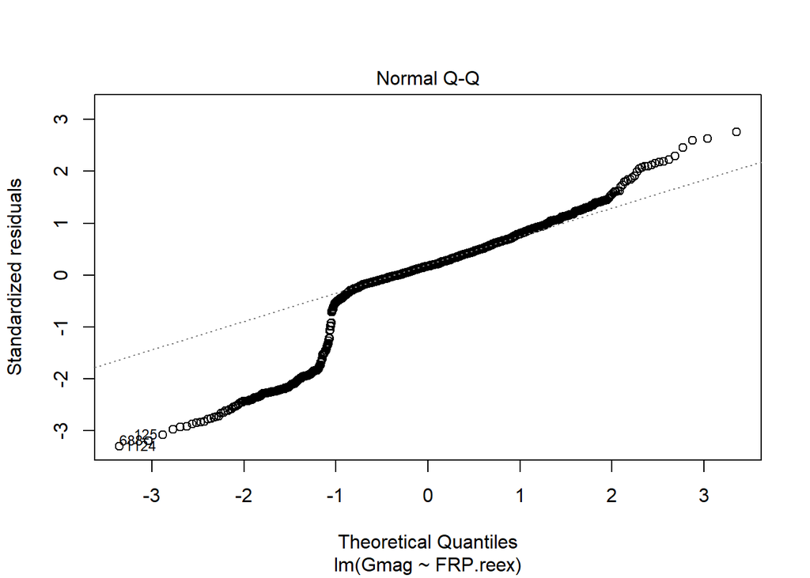

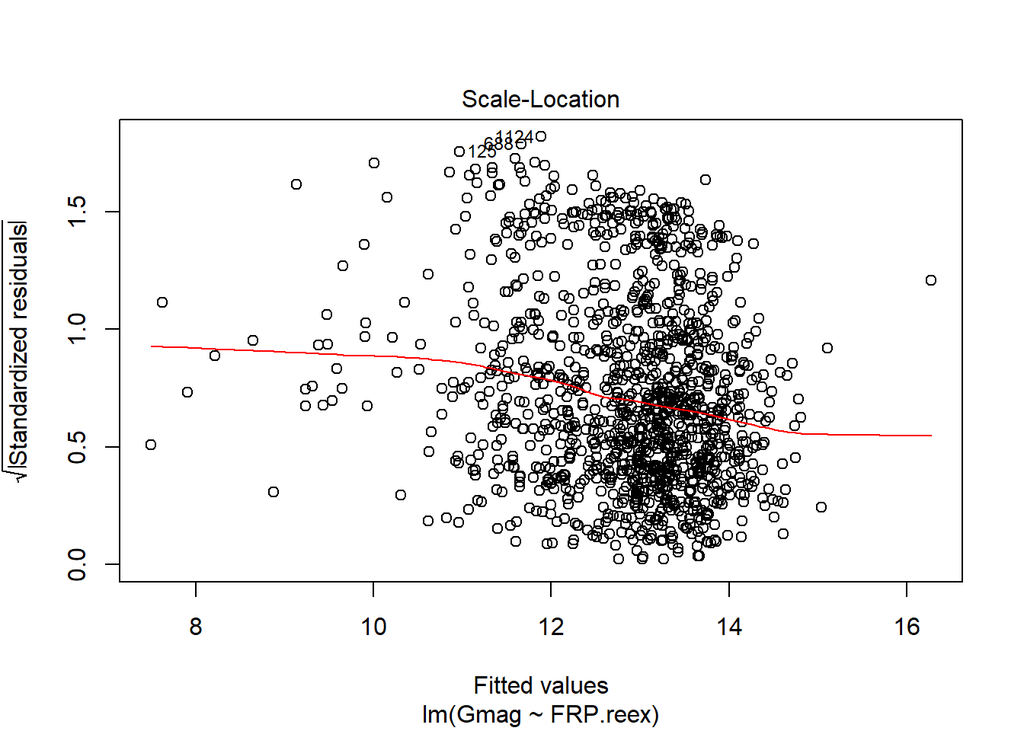

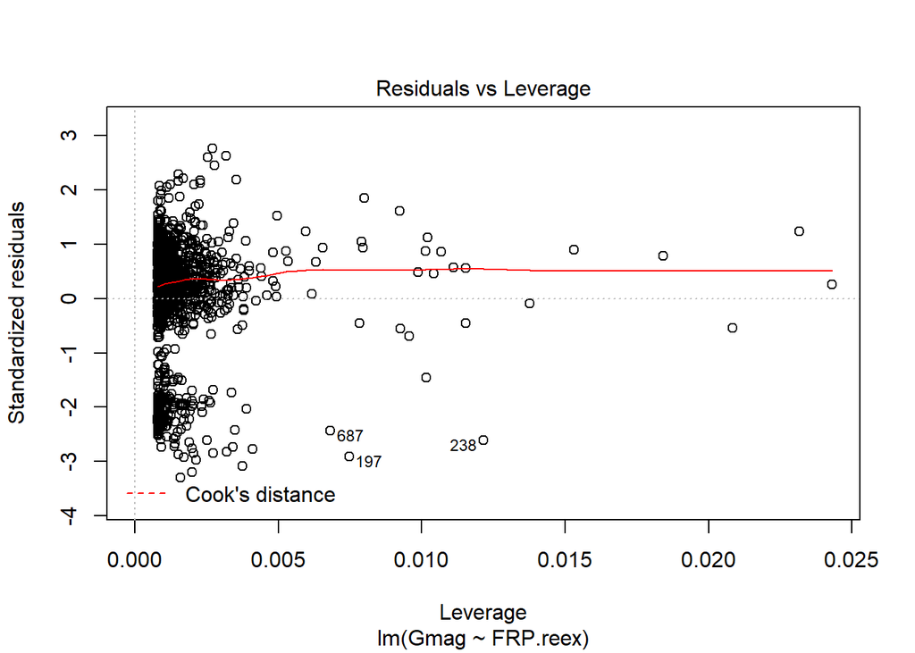

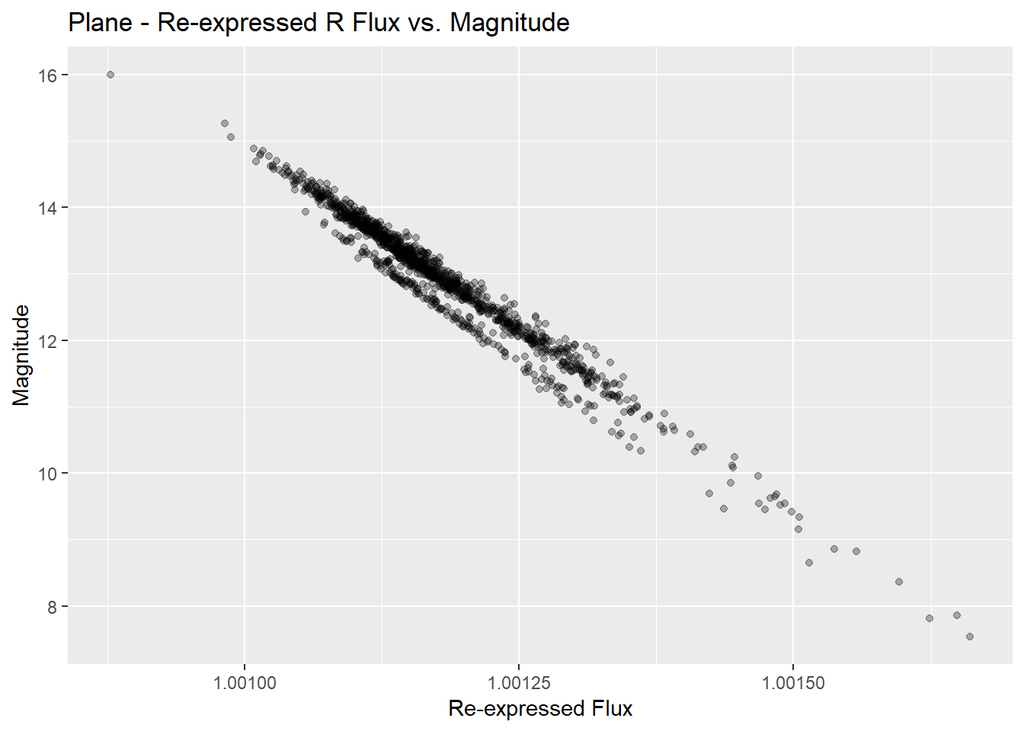

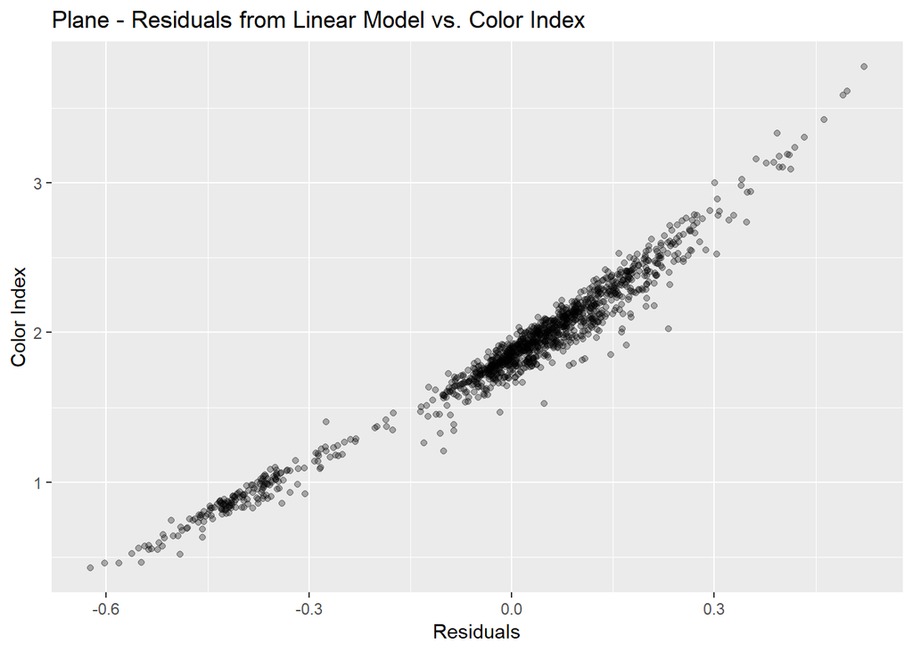

```
## [1] 0.9800703
```

```r
magflux_analysis(plane_cc, 'Plane')
```

Before looking at all of the results of this analysis, we note in the residuals from the linear reexpression, specifically in the “Residuals vs Leverage” plot, that there are a number of high-leverage outliers that are skewing the results. This is also evident in the “Residuals vs Fitted” plot as we see a cluster of points in the middle with just a few points on the right and left edges. Other samples are susceptible to skewed results due to outliers as well. Therefore, the following function will remove the Tukey outliers for each sample.

```r
remove_outliers <- function(df){
  out1 <- find_outliers(df$FRP)
  out2 <- find_outliers(df$Gmag)
  unique_out <- unique(c(out1, out2))
  df_new <- df[-unique_out,]
  df_new
}
```

Now we can re-assess for the plane sample.

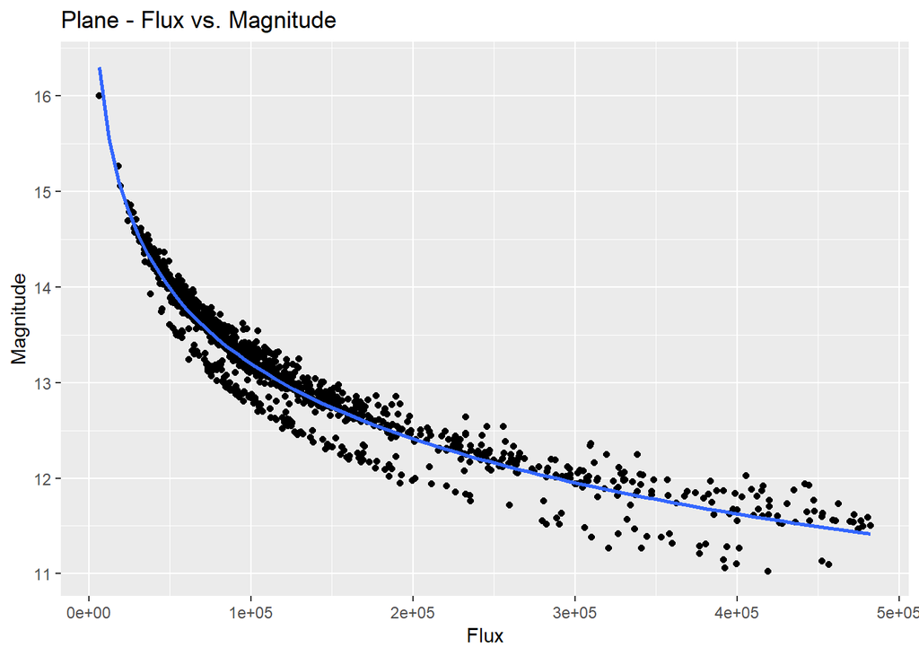

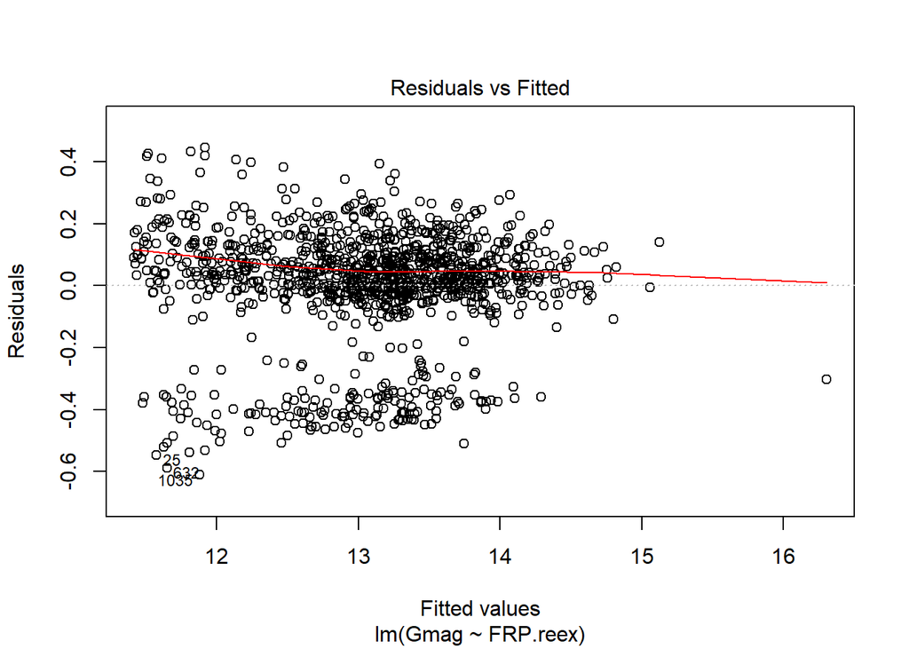

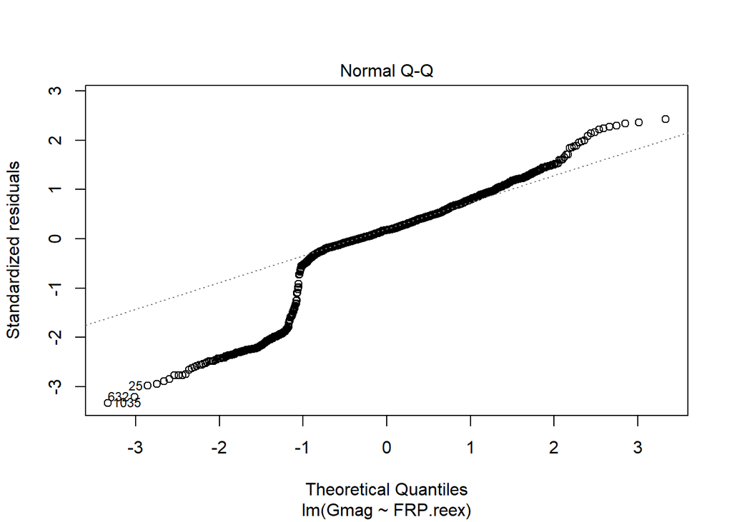

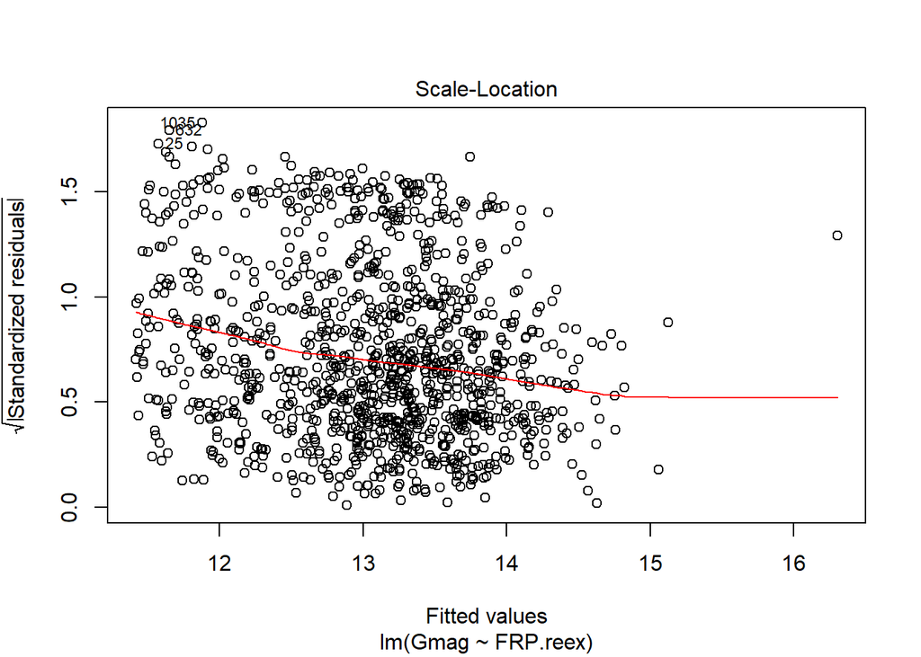

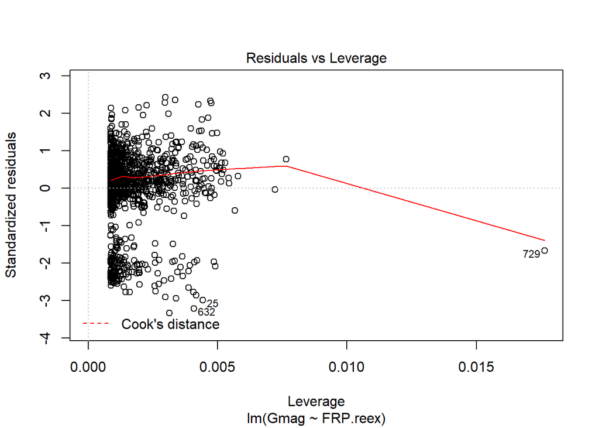

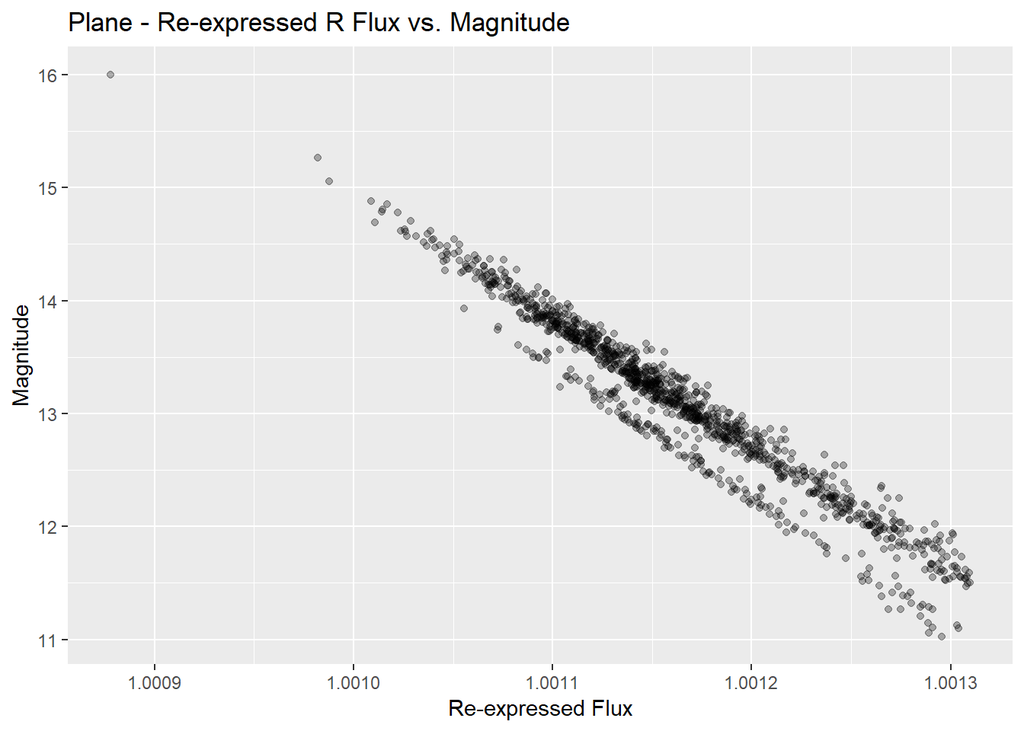

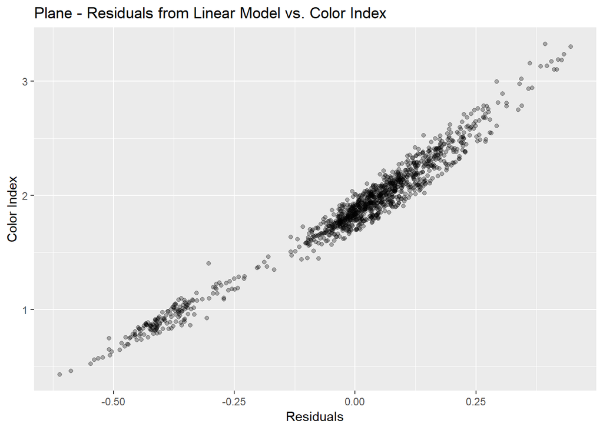

```
## [1] 0.9813442
```

```r
plane_new <- remove_outliers(plane_cc)
magflux_analysis(plane_new, 'Plane')
```

In the Flux vs. Magnitude plot, the raw relationship between magnitude and flux seems to fit a log curve relatively well. The points seem to cling to the fit line, althought there is a trail of points below the line. However, the curvature of the line makes it difficult to see the goodness of fit in areas where there is a high density of points. In order to better analyze the goodness of fit, we re-express this relationship as a linear relationship.

The Base R plots analyze the residuals of the linear fit. The first, “Residuals vs. Fitted”, shows randomness in the spread of points, apart from the anomaly of the separation of two chunks of data (as discussed above). The normal QQ plot leads us to believe that the data may not be normally distributed. Given the context of the linear model, this is not concerning and does not undermine our analysis. The randomness shown on the “Scale-location” plot is a good sign. There are now only a small handful of high-leverage points on the “Residuals vs Leverage” plot, so they are unlikely to skew results. Furthermore, these points are not outliers.

Finally, the residuals of the linear reexpression correlate very highly with the color index with a correlation of 0.981.This high correlation is shown in the positive slope in the graph of the residuals vs. color index.

Now to analyze the other two samples:

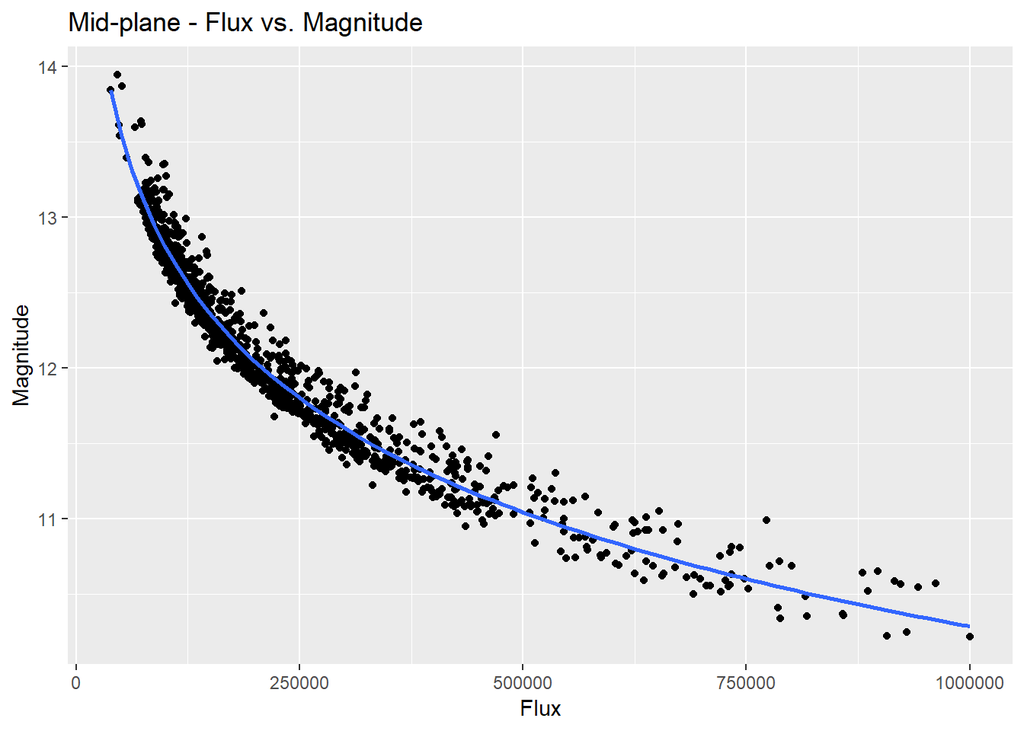

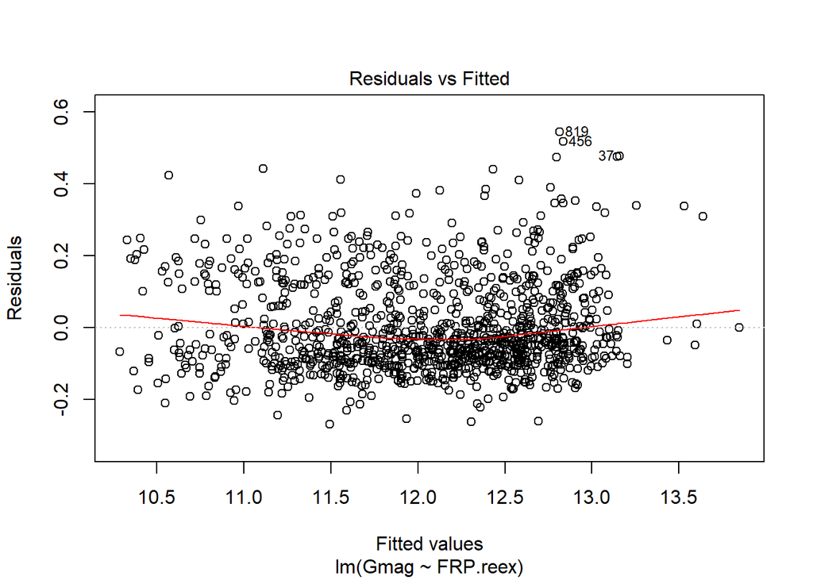

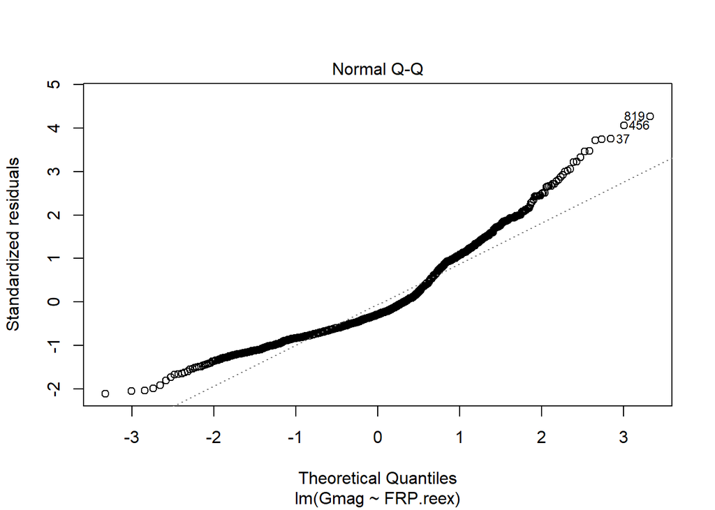

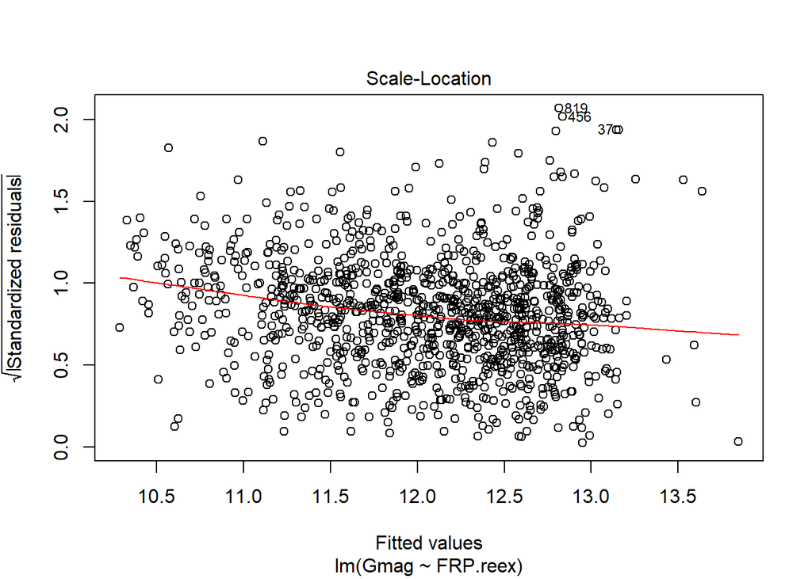

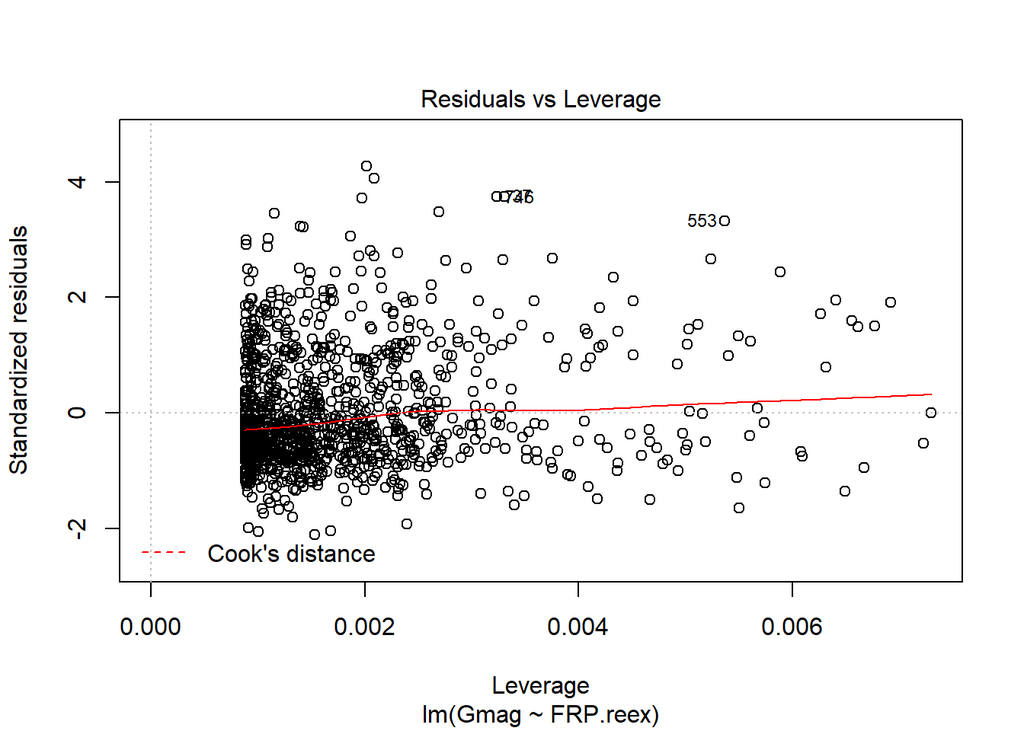

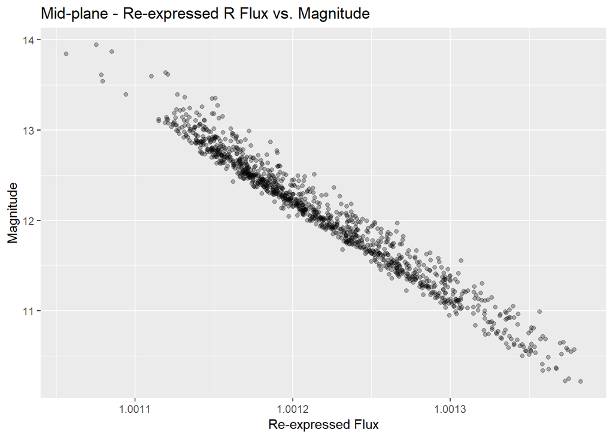

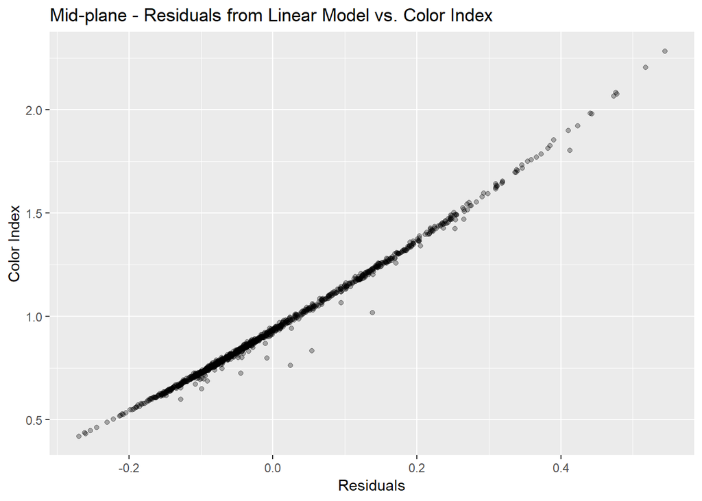

```
## [1] 0.9969416
```

```r
mid_new <- remove_outliers(mid_cc)
magflux_analysis(mid_new, 'Mid-plane')
```

In the Flux vs. Magnitude plot, the raw relationship between magnitude and flux seems to fit a log curve very well. The points seem to cling to the fit line, with points seeming to fall evenly above and below the line. However, the curvature of the line still makes it difficult to see the goodness of fit in areas where there is a high density of points. In order to better analyze the goodness of fit, we re-express this relationship as a linear relationship.

Finally, the residuals of the linear reexpression correlate very highly with the color index with a correlation of 0.997. This high correlation is shown in the positive slope in the graph of the residuals vs. color index.

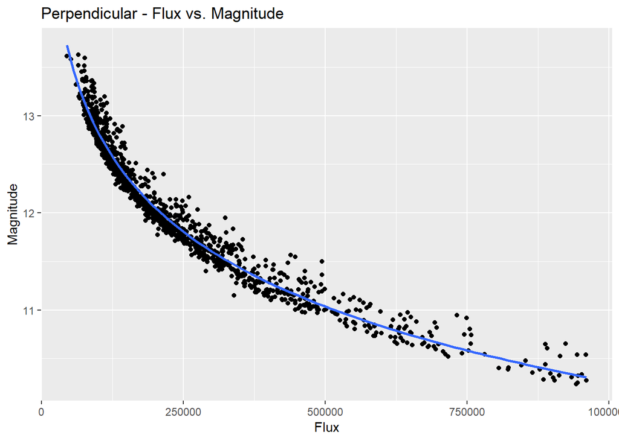

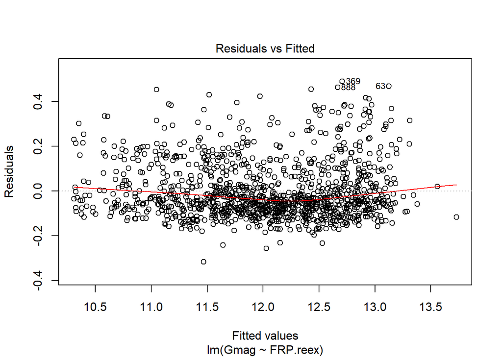

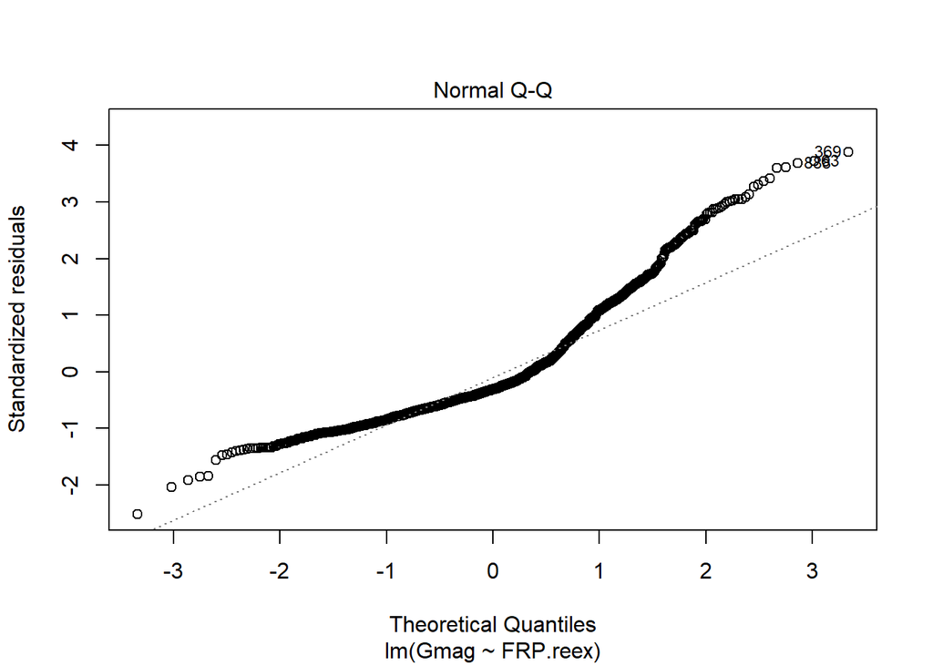

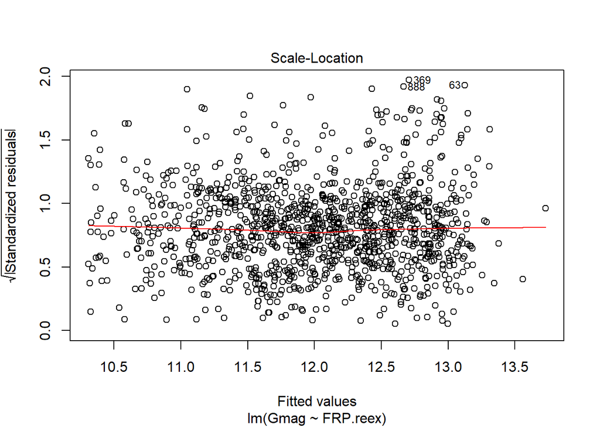

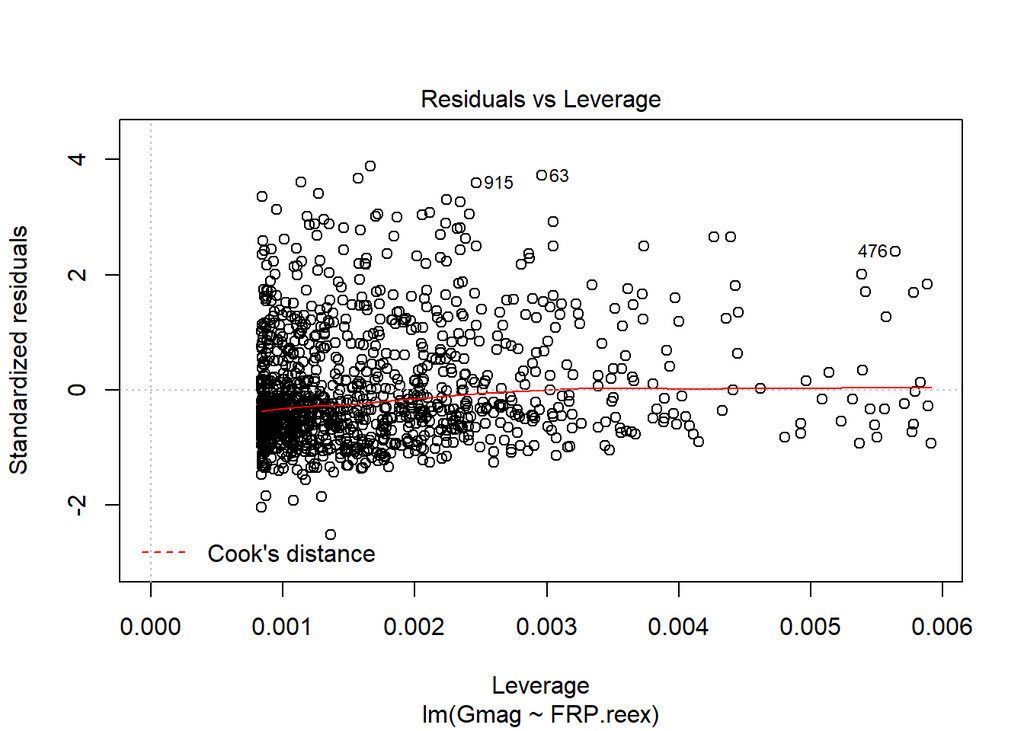

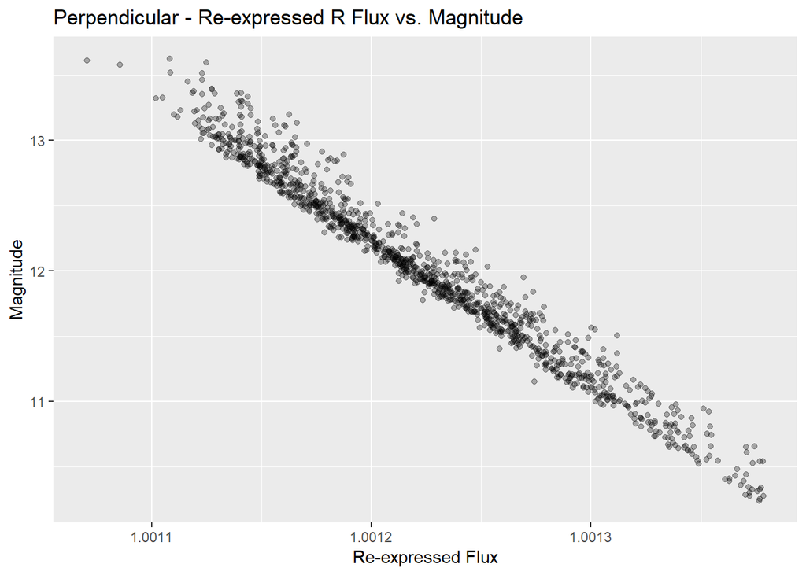

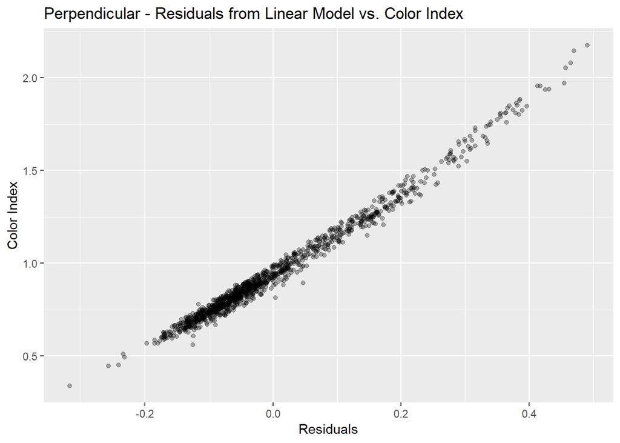

```
## [1] 0.9923314
```

```r
perp_new <- remove_outliers(perp_cc)
magflux_analysis(perp_new, 'Perpendicular')
```

The results from the perpendicular sample are nearly identical to those of the mid-plane sample.

The Flux vs. Magnitude plot demonstrates a good fit to the log curve with no irregularities. The linear reexpression shows a strong fit as well. The residuals demonstrate homoskedasticity and otherwise do not show any red flags.The residuals of the linear reexpression correlate very highly with the color index with a correlation of 0.992.

## Part 2: Magnitude and Error

For part 2 of this analysis, I seek to understand which error term is a better predictor of magnitude. There are ten error terms that describe the level of error for the collection of 10 parameters. Generally, if error is high, it is likely that the star is very dim (high magnitude). Which error terms guide this relationship? Correlate different kinds of error with magnitude + compare - the brighter the star, how much/what kinds of error decrease and by how much?

Here we do not expect the results to differ across samples, nor are we interested in a comparison. So, the combined data set will be used.

```r
head(all)
```

```
## # A tibble: 6 x 35
##   RA_ICRS e_RA_ICRS DE_ICRS e_DE_ICRS  Source   Plx  e_Plx   pmRA e_pmRA
##     <dbl>     <dbl>   <dbl>     <dbl>   <dbl> <dbl>  <dbl>  <dbl>  <dbl>
## 1    318.    0.0266    48.3    0.0288 2.17e18 0.314 0.0331  -1.37  0.056
## 2    318.    0.0211    48.4    0.023  2.17e18 0.924 0.0272 -13.6   0.043
## 3    318.    0.0237    48.3    0.0259 2.17e18 0.398 0.0306  -2.22  0.05
## 4    318.    0.0134    48.4    0.0146 2.17e18 0.419 0.0173  -3.61  0.028
## 5    318.    0.0229    48.3    0.0251 2.17e18 1.16  0.0273   8.19  0.045
## 6    318.    0.0195    48.4    0.0234 2.17e18 0.489 0.0257  -4.43  0.04
## # ... with 26 more variables: pmDE <dbl>, e_pmDE <dbl>, Dup <dbl>,
## #   FG <dbl>, e_FG <dbl>, Gmag <dbl>, e_Gmag <dbl>, FBP <dbl>,
## #   e_FBP <dbl>, BPmag <dbl>, e_BPmag <dbl>, FRP <dbl>, e_FRP <dbl>,
## #   RPmag <dbl>, e_RPmag <dbl>, Mode <dbl>, BP.RP <dbl>, RV <dbl>,
## #   e_RV <dbl>, fPriam <dbl>, Teff <dbl>, AG <dbl>, E.BP.RP. <dbl>,
## #   Rad <dbl>, Lum <dbl>, sample <dbl>
```

```r
all_err <- all[,c(15, 2,4,7,9,11,14,18,20,22,24)] #narrow to error columns
head(all_err)
```

```
## # A tibble: 6 x 11
##    Gmag e_RA_ICRS e_DE_ICRS  e_Plx e_pmRA e_pmDE  e_FG e_FBP e_BPmag e_FRP
##   <dbl>     <dbl>     <dbl>  <dbl>  <dbl>  <dbl> <dbl> <dbl>   <dbl> <dbl>
## 1  13.3    0.0266    0.0288 0.0331  0.056  0.05   33.6  82.0  0.0055 132.
## 2  12.0    0.0211    0.023  0.0272  0.043  0.038  50.6 177.   0.002  216.
## 3  13.0    0.0237    0.0259 0.0306  0.05   0.047  55.9  83.8  0.003  125.
## 4  13.5    0.0134    0.0146 0.0173  0.028  0.024  18.7  58.9  0.0025  82.0
## 5  11.1    0.0229    0.0251 0.0273  0.045  0.046 262.  340.   0.0019 518.
## 6  12.9    0.0195    0.0234 0.0257  0.04   0.039  50.0  83.9  0.0022 104.
## # ... with 1 more variable: e_RPmag <dbl>
```

A regression tree will be used in order to visualize how which error terms have the greatest effect on magnitude.

```r
colnames(all_err)
```

```
##  [1] "Gmag"      "e_RA_ICRS" "e_DE_ICRS" "e_Plx"     "e_pmRA"
##  [6] "e_pmDE"    "e_FG"      "e_FBP"     "e_BPmag"   "e_FRP"
## [11] "e_RPmag"
```

```r
tree_err = tree(Gmag~.,all_err)
summary(tree_err)
```

```
##
## Regression tree:
## tree(formula = Gmag ~ ., data = all_err)
## Variables actually used in tree construction:
## [1] "e_FG"  "e_FBP" "e_FRP"
## Number of terminal nodes:  8
## Residual mean deviance:  0.1521 = 591.6 / 3889
## Distribution of residuals:
##     Min.  1st Qu.   Median     Mean  3rd Qu.     Max.
## -2.18100 -0.22880 -0.02496  0.00000  0.21600  2.43300
```

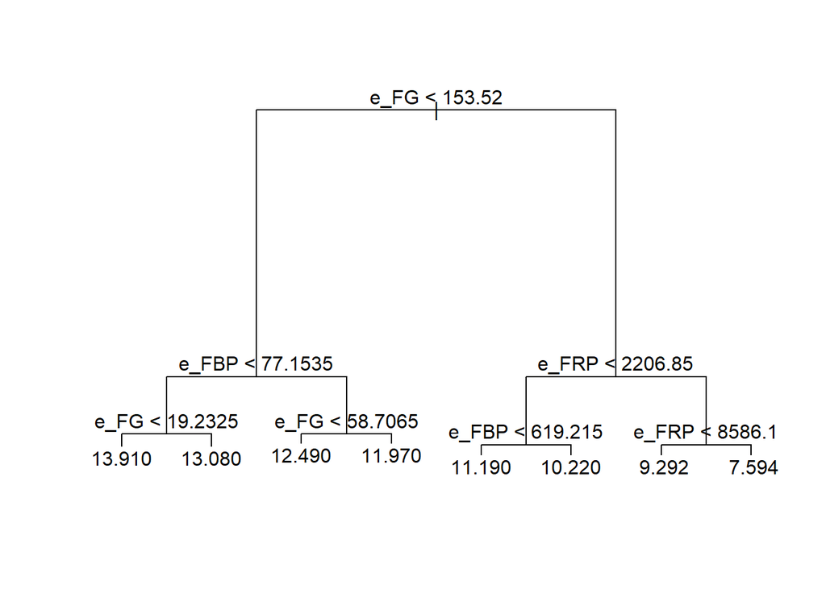

```r
plot(tree_err)
text(tree_err, pretty=0)
```

This tree has not yet been pruned. However, even if it had, it is hard to grasp wether the magnitude number is high or low based on the distribution of magnitudes. For easier interpretability, I will create a categorical variable indication that the bottom third of the sorted magnitudes are “Bright”, middle third are “Medium”, and top third are “Dim”.

```r
#create separations based on quantile
unit <- length(na.omit(all_err$Gmag))/3
sorted <- sort(na.omit(all_err$Gmag))
bottom <- sorted[ceiling(unit)]
top <- sorted[ceiling(2*unit)]

#determine level variable by separations
level = ifelse(all_err$Gmag <=bottom,"Bright",ifelse(all_err$Gmag <=top, "Medium", "Dim"))
all_err_new <- data.frame(all_err ,level)
tree_err1 <- tree(level ~. -Gmag, all_err_new)
```

```r
summary(tree_err1)
```

```
##
## Classification tree:
## tree(formula = level ~ . - Gmag, data = all_err_new)
## Variables actually used in tree construction:
## [1] "e_FG"    "e_FBP"   "e_BPmag"
## Number of terminal nodes:  8
## Residual mean deviance:  0.6254 = 2432 / 3889
## Misclassification error rate: 0.1409 = 549 / 3897
```

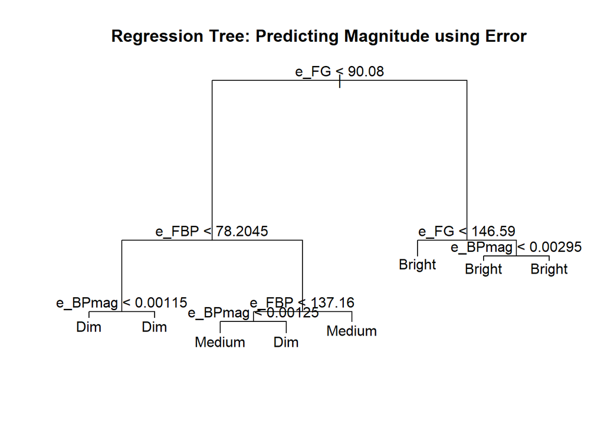

```r
plot(tree_err1)
text(tree_err1, pretty=0)
title("Regression Tree: Predicting Magnitude using Error")
```

```r
pruned <- prune.misclass(tree_err1, best=4)
summary(pruned)
```

```
##
## Classification tree:
## snip.tree(tree = tree_err1, nodes = 3:4)
## Variables actually used in tree construction:
## [1] "e_FG"    "e_FBP"   "e_BPmag"
## Number of terminal nodes:  5
## Residual mean deviance:  0.7732 = 3009 / 3892
## Misclassification error rate: 0.1409 = 549 / 3897
```

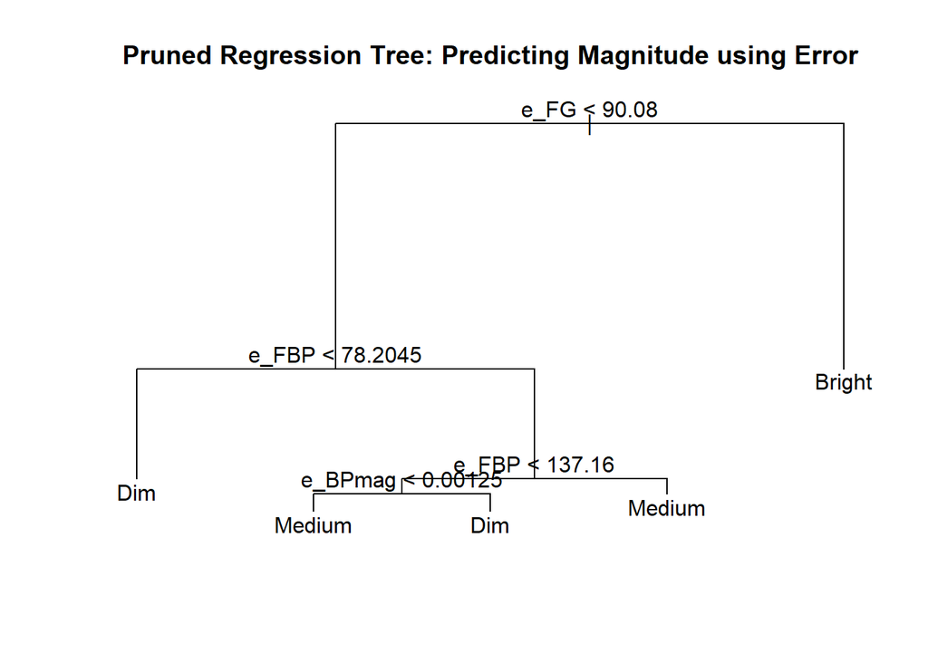

```r
plot(pruned)
text(pruned ,pretty =0)
title("Pruned Regression Tree: Predicting Magnitude using Error")
```

This regression tree is very telling about which error terms play the largest role in predicting the magnitude. The G flux error plays a large role, being the sole determiner between whether a star is predicted to be Bright or Medium/Dim. All observations with G Flux error greater than 90.08 are predicted to be Bright. Of those that are not, those with B flux errors of less than 78.2045 are predicted to be Dim. Those with larger B flux errors could be Medium or Dim depending on B flux error and BP magnitude error.

## Part 3: Radial Velocity

In part three of this analysis, I seek to analyze the distribution of the radial velocity. When this data set is narrowed to complete cases, it should limited to observations with magnitudes large enough to accurately measure motion. Therefore, we would not expect any other relationship between brightness and motion. Furthermore, we would expect to see that the distribution of radial velocities is normal or fits a normal Guassian curve.

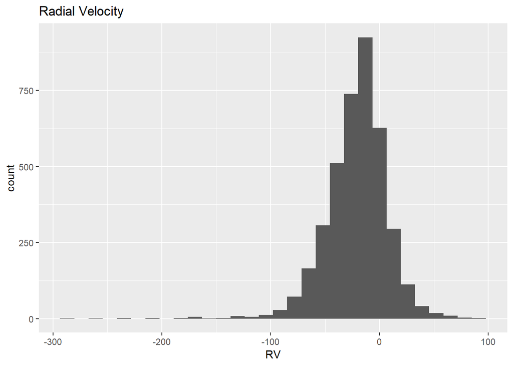

```r
ggplot(all, aes(RV)) + geom_histogram() + ggtitle("Radial Velocity") #Yikes outliers
```

```r
head(all)
```

```
## # A tibble: 6 x 35
##   RA_ICRS e_RA_ICRS DE_ICRS e_DE_ICRS  Source   Plx  e_Plx   pmRA e_pmRA
##     <dbl>     <dbl>   <dbl>     <dbl>   <dbl> <dbl>  <dbl>  <dbl>  <dbl>
## 1    318.    0.0266    48.3    0.0288 2.17e18 0.314 0.0331  -1.37  0.056
## 2    318.    0.0211    48.4    0.023  2.17e18 0.924 0.0272 -13.6   0.043
## 3    318.    0.0237    48.3    0.0259 2.17e18 0.398 0.0306  -2.22  0.05
## 4    318.    0.0134    48.4    0.0146 2.17e18 0.419 0.0173  -3.61  0.028
## 5    318.    0.0229    48.3    0.0251 2.17e18 1.16  0.0273   8.19  0.045
## 6    318.    0.0195    48.4    0.0234 2.17e18 0.489 0.0257  -4.43  0.04
## # ... with 26 more variables: pmDE <dbl>, e_pmDE <dbl>, Dup <dbl>,
## #   FG <dbl>, e_FG <dbl>, Gmag <dbl>, e_Gmag <dbl>, FBP <dbl>,
## #   e_FBP <dbl>, BPmag <dbl>, e_BPmag <dbl>, FRP <dbl>, e_FRP <dbl>,
## #   RPmag <dbl>, e_RPmag <dbl>, Mode <dbl>, BP.RP <dbl>, RV <dbl>,
## #   e_RV <dbl>, fPriam <dbl>, Teff <dbl>, AG <dbl>, E.BP.RP. <dbl>,
## #   Rad <dbl>, Lum <dbl>, sample <dbl>
```

The histogram for radial velocity indicates that this variable may indeed be normally distributed, but outliers make it difficult to tell. Furthermore, histograms can be misleading at times because with an increase in count comes an increase in variability.

Remove outliers and plot a new histogram:

```r
outliers <- find_outliers(all$RV)
clean <- all[-outliers,]
fivenum(clean$RV)
```

```
## [1] -97.740 -34.970 -18.260  -4.525  56.620
```

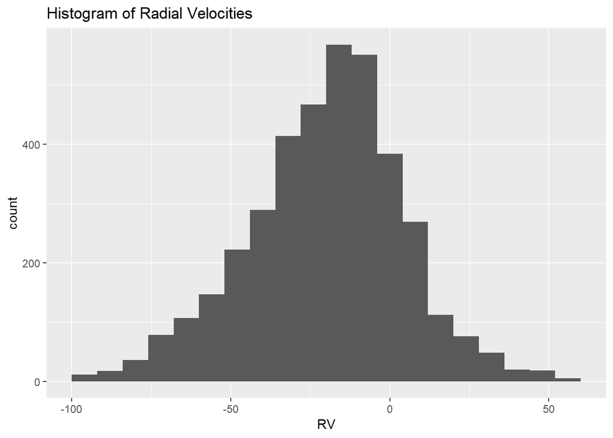

```r
ggplot(clean, aes(RV)) + geom_histogram(binwidth=8) + ggtitle("Histogram of Radial Velocities")
```

Removing outliers and using five number summary to determine a reasonable binwidth yields a much more explanatory histogram. While the distribution appears approximately normal, there are appears to be a slight left skew. However, it is difficult to determine whether this is a result of the higher variability associated with histogram bars of higher counts. To remove this dependency, I’ll create a rootogram (use root frequencies).

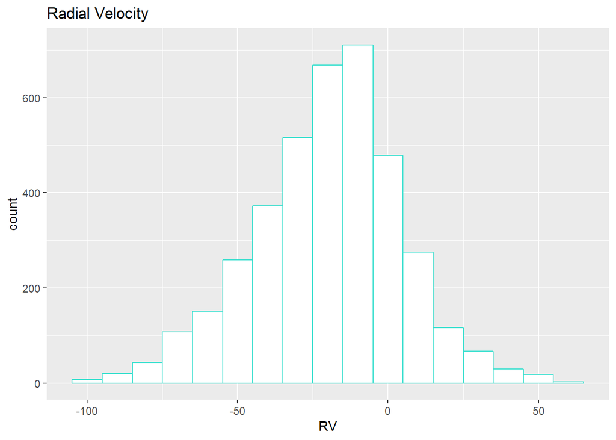

```r
bins <-seq(-105, 65, 10)
bin.mids <- (bins[-1]+bins[-length(bins)])/2
ggplot(clean ,aes(RV))+geom_histogram(breaks = bins,fill = "white",color = "turquoise") + ggtitle("Radial Velocity")
```

```r
p <- ggplot(clean, aes(RV))+geom_histogram(breaks = bins)
out <-ggplot_build(p)$data[[1]]
select(out, count, x, xmin, xmax)
```

```
##    count    x xmin xmax
## 1      7 -100 -105  -95
## 2     20  -90  -95  -85
## 3     43  -80  -85  -75
## 4    107  -70  -75  -65
## 5    151  -60  -65  -55
## 6    259  -50  -55  -45
## 7    372  -40  -45  -35
## 8    516  -30  -35  -25
## 9    668  -20  -25  -15
## 10   711  -10  -15   -5
## 11   478    0   -5    5
## 12   275   10    5   15
## 13   116   20   15   25
## 14    67   30   25   35
## 15    29   40   35   45
## 16    18   50   45   55
## 17     2   60   55   65
```

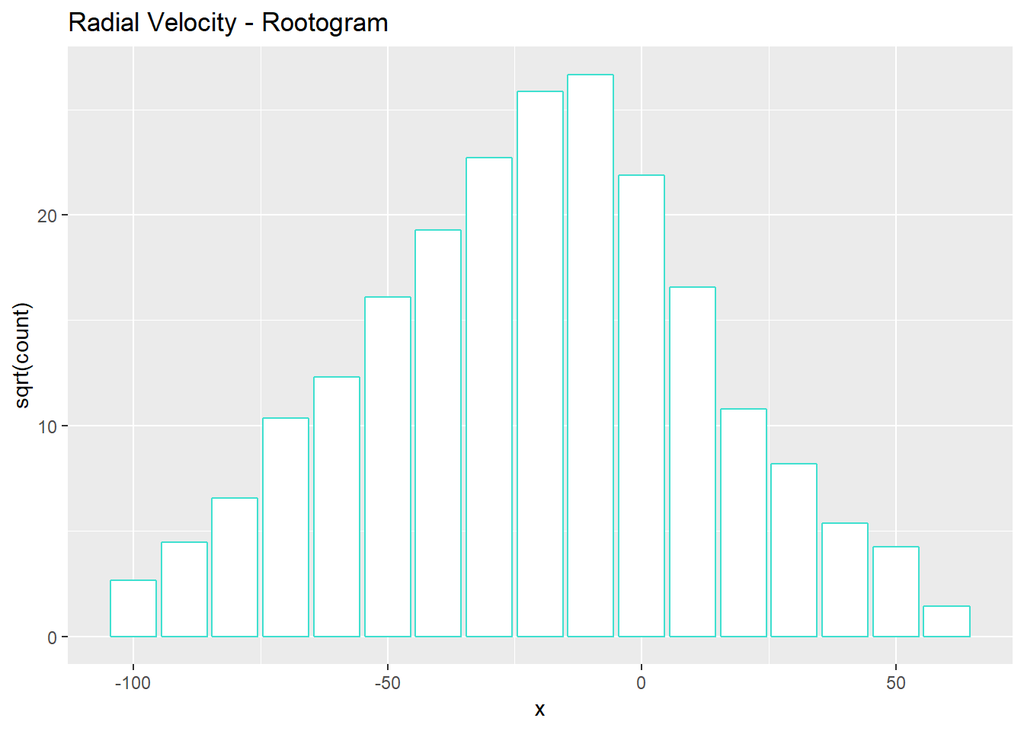

```r
ggplot(out,aes(x,sqrt(count)))+geom_col(fill = "white",color = "turquoise") + ggtitle("Radial Velocity - Rootogram")
```

This operation seems to stabilizes the variability of counts between high-count and low-count areas of the plot. While the curve is not centered at zero, a visual assessment indicates that the Radial Velocity follows a normal distribution.

# Conclusion

The question I sought to help answer in this analysis was the following:

In what ways are the relationships between quantities measured by Gaia made evident in the data? How are well-understood dependencies represented in the data? In what ways can less-familiar relationships be expressed?

In part one, the analysis of the relationship between magnitude and flux demonstrated how a well-understood dependency is represented in the data. It is common knowledge among astronomers that there is a log relationship between magnitude in flux. My linear reexpression confirmed the validity of this relationship and highlighted how this well-understood relationship is expressed in new data collected from the Gaia space mission.

In part two, the analysis of the relationship between magnitude and error highlighted branched off the well-known idea that the error in observation of stellar parameters is related to the magnitude of the star. However, this analysis branches into uncharted territory in exploring which error parameters best predict magnitude.

In part three, the distribution of radial velocity encompasses a topic that may be well known but is not well discussed to my knowledge. There is not a relationship between motion and brightness in this context, but it is unclear whether scientific interests has led researchers to prove a normal distribution. It is clear that this analysis is extremely valuable in providing insight to the question at hand.